# GLM Trees - Example using ILEC 2009-2015 Term

Philip Adams

February 10, 2020

# Summary

This R markdown includes the R code which will lead from the original data file to the final GLM tree plot. The data cleanup portion is provided for completeness. However, the actual load and cleanup steps are not executed. If you would like to execute them, change the chunk option to eval=TRUE.

# Required packages

```r
library(rio)
library(data.table)

library(partykit)
```

```r
library(openxlsx)
library(ggplot2)
library(ggpmisc)
library(plyr)

library(gifski)
library(treemap)
```

# Data Preparation

The file can be downloaded from http://cdn-files.soa.org/research/2009-15_Data_20180601.zip. Although labeled as a CSV, it is in fact a tab-delimited text file (TSV).

## Data Load

The rio package is tremendously useful in this instance, as it takes care of all the unpacking, formatting, and delivery of the data into a data.table object in a single call.

The data.table package is used for performance reasons. The only downside is that data.table expressions can be challenging to decipher.

```r
ilec.dat <- rio::import("2009-15_Data_20180601.zip",setclass="data.table",format="tsv")
```

If you have already saved the ilec.dat object as I have, you can load an RData file with it.

```r
load('./Work.RData')
```

## Data Cleanup

The fields have spaces in their names. Rather than wrap every name with ` `, replace the spaces with dots. Note that the make.names function does the same thing.

```r
names(ilec.dat) <- gsub(" ",".",names(ilec.dat),fixed = TRUE)
```

While rio is helpful, one still has to translate data and convert to factors as needed.

- Age basis is translated to its text equivalent.
- Columns that should be factors are converted to factors.
- Face amount bands are reordered to reflect the natural ordering of the bands.

```r
ilec.dat[,Age.Basis:=ifelse(Age.Basis==1,"ALB","ANB")]

ilec.dat[,
         `:=`(Common.Company.Indicator.57=factor(Common.Company.Indicator.57),
              Preferred.Indicator=factor(Preferred.Indicator),
              Gender=factor(Gender),
              Smoker.Status=factor(`Smoker.Status`),
              Insurance.Plan=factor(`Insurance.Plan`),
              Age.Basis=factor(`Age.Basis`),
              Face.Amount.Band=factor(`Face.Amount.Band`),
              Number.of.Preferred.Classes=factor(`Number.of.Preferred.Classes`),
              Preferred.Class=factor(`Preferred.Class`),
              SOA.Anticipated.Level.Term.Period=factor(`SOA.Anticipated.Level.Term.Period`),
              SOA.Guaranteed.Level.Term.Period=factor(`SOA.Guaranteed.Level.Term.Period`),
              SOA.Post.level.term.indicator=factor(`SOA.Post.level.term.indicator`),
              Select_Ultimate_Indicator=factor(Select_Ultimate_Indicator)
         )
         ]

# The levels are declared explicitly to enforce the given ordering. Otherwise, it is in alphabetical order.
ilec.dat[,Face.Amount.Band:=factor(Face.Amount.Band,
                                   levels=c("1-9999",
                                            "10000-24999",
                                            "25000-49999",
                                            "50000-99999",
                                            "100000-249999",
                                            "250000-499999",
                                            "500000-999999",
                                            "1000000-2499999",
                                            "2500000-4999999",
                                            "5000000-9999999",
                                            "10000000+"))]
```

Preferred classes are encoded as separate fields, yet there are strong dependencies between these fields. Moreover, the interpretation of preferred class is contingent on the context of the other two.

- There are three smoker classes, non-smoker, smoker, and unismoke
- The range of Number.of.Preferred.Classes is 1-4 for non-smokers, 1-2 for smokers, and 1 for unismoke.
- Preferred classes are ranked in order of increasing mortality.
- Preferred.class has very different meanings depending on Number.of.Preferred.Classes. Preferred class 2 of a 2-class system is residual standard, while preferred class 2 of a 4-class system is second-best preferred.
- NAs are converted to 1

```r
# Set the UW class by merging the fields Smoker.Status, Number.of.Preferred.Classes, Preferred.Class
#
# Pattern is Txy
#  - T is one of N, S, or U for NonSmoker, Smoker, Unismoke
#  - x is number of preferred classes
#  - y is preferred class
#
# This has the effect of ordering the factors in a nice way.
#
#
ilec.dat[,UW.Class:=
           paste0(substr(Smoker.Status,1,1),
                  ifelse(is.na(Number.of.Preferred.Classes),1,as.character(Number.of.Preferred.Classes)),
                  ifelse(is.na(Preferred.Class),1,as.character(Preferred.Class))
           )
         ]

ilec.dat[,UW.Class:=factor(UW.Class)]
```

What follows are various groupings of the data to facilitate exploration and model building.

```r
# Generic attained age, issue age, and duration groupings.
ilec.dat[,`:=`(AA.Grp=cut(Attained.Age,right=F,breaks=c(0,18,30,40,50,60,70,80,90,121),
                          labels=c("00-17","18-29","30-39","40-49","50-59","60-69","70-79","80-89","90+")),
               Dur.Grp=cut(Duration,right=F,breaks=c(1,2,3,6,11,16,21,26,31,120),
                           labels=c("01-01","02-02","03-05","06-10","11-15","16-20","21-25","26-30","31+")),
               IY.Grp=cut(Issue.Year,right=F,breaks=c(1900,1930,1940,1950,1960,1970,1980,1990,2000,2010,2016),
                          labels=c("1900-1929","1930-1939","1940-1949",
                                   "1950-1959","1960-1969","1970-1979",
                                   "1980-1989","1990-1999","2000-2009","2010-2015")))]

# Second groupding of issue year which combines <= 1959
ilec.dat[,IY.Grp2:=cut(Issue.Year,right=F,breaks=c(1900,1960,1970,1980,1990,2000,2010,2016),
                       labels=c("1900-1959","1960-1969","1970-1979","1980-1989","1990-1999","2000-2009","2010-2015"))]

# This grouping of face amount band is useful for perm
ilec.dat[,FA.Band.2:="250000+"]
ilec.dat[Face.Amount.Band %in% c("1-9999"), FA.Band.2:="1-9999"]
ilec.dat[Face.Amount.Band %in% c("10000-24999","25000-49999"),FA.Band.2:="10000-49999"]
ilec.dat[Face.Amount.Band %in% c("50000-99999"), FA.Band.2:="50000-99999"]
ilec.dat[Face.Amount.Band %in% c("100000-249999"), FA.Band.2 :="100000-249999"]
ilec.dat[,FA.Band.2:=factor(FA.Band.2,levels=c("1-9999","10000-49999","50000-99999","100000-249999","250000+"),
                                               ordered=T)]

# This is useful for detecting effects by year not adequately modeled by linear terms.
# Each year except for base year of 2009 appears with its own coefficient
ilec.dat[,OY.Factor:=factor(Observation.Year)]

ilec.dat[,OYGTE2011:=Observation.Year >= 2011]
ilec.dat[,Observation.Year.Centered := Observation.Year - 2012]


# This grouping of face amount band is useful for term products
ilec.dat[,FA.Band.3:="1000000+"]
ilec.dat[Face.Amount.Band %in% c("1-9999"), FA.Band.3:="1-9999"]
ilec.dat[Face.Amount.Band %in% c("10000-24999","25000-49999"),FA.Band.3:="10000-49999"]
ilec.dat[Face.Amount.Band %in% c("50000-99999"), FA.Band.3:="50000-99999"]
ilec.dat[Face.Amount.Band %in% c("100000-249999"), FA.Band.3 :="100000-249999"]
ilec.dat[Face.Amount.Band %in% c("250000-499999"), FA.Band.3 :="250000-499999"]
ilec.dat[Face.Amount.Band %in% c("500000-999999"), FA.Band.3 :="500000-999999"]
ilec.dat[,FA.Band.3:=factor(FA.Band.3,
                            levels=c("1-9999",
                                     "10000-49999",
                                     "50000-99999",
                                     "100000-249999",
                                     "250000-499999",
                                     "500000-999999",
                                     "1000000+"),
                            ordered = T)] # Change to T when working with glmtree


ilec.dat[,FA.Band.4:="1000000+"]
ilec.dat[Face.Amount.Band %in% c("1-9999"), FA.Band.4:="1-9999"]
ilec.dat[Face.Amount.Band %in% c("10000-24999","25000-49999"),FA.Band.4:="10000-99999"]
ilec.dat[Face.Amount.Band %in% c("50000-99999"), FA.Band.4:="10000-99999"]
ilec.dat[Face.Amount.Band %in% c("100000-249999"), FA.Band.4 :="100000-249999"]
ilec.dat[Face.Amount.Band %in% c("250000-499999"), FA.Band.4 :="250000-499999"]
ilec.dat[Face.Amount.Band %in% c("500000-999999"), FA.Band.4 :="500000-999999"]
ilec.dat[,FA.Band.4:=factor(FA.Band.4,
                            levels=c("1-9999",
                                     "10000-99999",
                                     "100000-249999",
                                     "250000-499999",
                                     "500000-999999",
                                     "1000000+"),
                            ordered = T)] # Change to T when working with glmtree

# These groupings of term length were ultimately not used.
ilec.dat[,SOA.Anticipated.Level.Term.Period.2:="Other"]
ilec.dat[SOA.Anticipated.Level.Term.Period %in% c('5yr anctipated', '10 yr anticipated','15 yr anticipated'),
         SOA.Anticipated.Level.Term.Period.2:=SOA.Anticipated.Level.Term.Period]
ilec.dat[,SOA.Anticipated.Level.Term.Period.2 := factor(SOA.Anticipated.Level.Term.Period.2)]

ilec.dat[,SOA.Guaranteed.Level.Term.Period.2 := "Other"]
ilec.dat[SOA.Guaranteed.Level.Term.Period %in% c("5 yr guaranteed","10 yr guaranteed","15 yr guaranteed"),
         SOA.Guaranteed.Level.Term.Period.2 := SOA.Guaranteed.Level.Term.Period]
ilec.dat[,SOA.Guaranteed.Level.Term.Period.2:=factor(SOA.Guaranteed.Level.Term.Period.2)]

ilec.dat[,Ant.Guar.Period:=paste(as.character(SOA.Anticipated.Level.Term.Period),"_",
                                 as.character(SOA.Guaranteed.Level.Term.Period),sep="")]
ilec.dat[,Ant.Guar.Period:=factor(Ant.Guar.Period)]



# When building splines that vary by factors, one can only supply a single factor. Thus, if you want
# a spline for each of six combinations of gender and smoker status, a single factor has to be created.
ilec.dat[,GenderSM:=factor(paste0(substr(as.character(Gender),1,1),substr(as.character(Smoker.Status),1,1)))]


# Cleaning this up was useful for the tree models.
# Because of the combinatorial explosion of searching for subgroup splits for
# UW.Class (8191 to search over for 14 levels), it is easier on the optimizer to use the components.
#
# However, lack of preferred class systems is encoded as an NA. While this is nominally accurate,
# really what is being encoded is the number of underwriting classes and rank within that system.
#
# Absence of a system is equivalent to having just one class, with one being the rank within it. Thus,
# replace all the NAs with 1.
ilec.dat[,Preferred.Class:=as.character(Preferred.Class)]
ilec.dat[is.na(Preferred.Class),Preferred.Class:="1"]
ilec.dat[,Preferred.Class:=factor(Preferred.Class)]

ilec.dat[,Number.of.Preferred.Classes:=as.character(Number.of.Preferred.Classes)]
ilec.dat[is.na(Number.of.Preferred.Classes),Number.of.Preferred.Classes:="1"]
ilec.dat[,Number.of.Preferred.Classes:=factor(Number.of.Preferred.Classes)]
```

# GLM Trees

It is not necessary to carry all the data and detail. Compressing the data facilitates model building at the cost of some finer details.

To facilitate code reuse and reduce typing, I took advantage of some functionality in data.table to organize that task.

```r
feat.vec <- c("Observation.Year", "Gender","Age.Basis","FA.Band.3", "OYGTE2011",
              "SOA.Anticipated.Level.Term.Period","SOA.Guaranteed.Level.Term.Period",
              "Smoker.Status","Number.of.Preferred.Classes","Preferred.Class",
              "AA.Grp","Dur.Grp","IY.Grp2", "UW.Class","SOA.Post.level.term.indicator")
out.vec <- c("Number.of.Deaths","Death.Claim.Amount","Policies.Exposed","Amount.Exposed",
             "Expected.Death.QX2015VBT.by.Policy","Expected.Death.QX2015VBT.by.Amount")
all.vec <- union(feat.vec,out.vec)

ileccols.features <- which(names(ilec.dat) %in% feat.vec)
ileccols.outcomes <- which(names(ilec.dat) %in% out.vec)
ileccols <- union(ileccols.features,ileccols.outcomes)

ilec.dat.test <- ilec.dat[ Insurance.Plan == "Term",..all.vec]

ileccols.features <- which(names(ilec.dat.test) %in% feat.vec)
ileccols.outcomes <- which(names(ilec.dat.test) %in% out.vec)
ileccols <- union(ileccols.features,ileccols.outcomes)

# Summarize out excess detail, and get rid of rows with 0 exposure
ilec.dat.test <- ilec.dat.test[,.(Number.of.Deaths=sum(Number.of.Deaths),
                                  Policies.Exposed=sum(Policies.Exposed),
                                  Expected.Death.QX2015VBT.by.Policy=sum(Expected.Death.QX2015VBT.by.Policy),
                                  Death.Claim.Amount=sum(Death.Claim.Amount),
                                  Amount.Exposed=sum(Amount.Exposed),
                                  Expected.Death.QX2015VBT.by.Amount=sum(Expected.Death.QX2015VBT.by.Amount)),
                               by=feat.vec][Policies.Exposed > 0,]

# A legacy from previous coding.
ilec.dat.test[,Number.of.Preferred.Classes:=as.character(Number.of.Preferred.Classes)]
ilec.dat.test[is.na(Number.of.Preferred.Classes),Number.of.Preferred.Classes:="1"]
ilec.dat.test[,Number.of.Preferred.Classes:=factor(Number.of.Preferred.Classes)]

ilec.dat.test[,Preferred.Class:=as.character(Preferred.Class)]
ilec.dat.test[is.na(Preferred.Class),Preferred.Class:="1"]
ilec.dat.test[,Preferred.Class:=factor(Preferred.Class)]

ileccols.features <- which(names(ilec.dat.test) %in% feat.vec)
ileccols.outcomes <- which(names(ilec.dat.test) %in% out.vec)
ileccols <- union(ileccols.features,ileccols.outcomes)

ilec.dat.test[,Ones:=rep.int(1,nrow(ilec.dat.test))]
```

## Custom code

```r
source('Predicate Cleanup.R')
source('my.glmtree.R')
```

```r
glmtree.mod.term.0 <- my.glmtree(Number.of.Deaths ~ Observation.Year |
                                   Gender + Age.Basis + FA.Band.3 + SOA.Anticipated.Level.Term.Period + OYGTE2011 +
                                   SOA.Guaranteed.Level.Term.Period +
                                   SOA.Post.level.term.indicator +
                                   Smoker.Status + Number.of.Preferred.Classes + Preferred.Class + Dur.Grp + AA.Grp + IY.Grp2,
                                 data=ilec.dat.test,
                                 family=poisson,
                                 offset=log(Expected.Death.QX2015VBT.by.Policy),
                                 weights = Expected.Death.QX2015VBT.by.Policy,
                                 glm.weights=ilec.dat.test$Ones,
                                 verbose=T,
                                 minsize=1000*10, # This is minimum expected claim count
                                 prune="aic"
)
```

```
##
## -- Node 1 ---------------------------------
## Number of observations: 207993.983067504
##
## Parameter instability tests:
##                 Gender    Age.Basis FA.Band.3
## statistic 7.369015e+01 1.173761e+02  4972.535
## p.value   1.295179e-15 4.227130e-25     0.000
##           SOA.Anticipated.Level.Term.Period    OYGTE2011
## statistic                      6.468107e+02 9.538950e+01
## p.value                       7.413825e-128 6.869019e-19
##           SOA.Guaranteed.Level.Term.Period SOA.Post.level.term.indicator
## statistic                     6.514363e+02                      2092.893
## p.value                      7.657860e-129                         0.000
##           Smoker.Status Number.of.Preferred.Classes Preferred.Class
## statistic  1.115395e+02                    2906.233    1.155378e+03
## p.value    4.441807e-22                       0.000   2.823298e-245
##                 Dur.Grp       AA.Grp       IY.Grp2
## statistic  1.363886e+03 3.126738e+02  9.642811e+02
## p.value   1.225079e-279 7.824514e-56 1.159245e-197
##
## Best splitting variable: FA.Band.3
## Perform split? yes
## Selected split: <= 50000-99999 | > 50000-99999
##
## -- Node 2 ---------------------------------
## Number of observations: 49380.8803004255
##
## Parameter instability tests:
##                 Gender    Age.Basis     FA.Band.3
## statistic 3.951746e+01 1.910095e+02  6.399756e+02
## p.value   3.410646e-08 4.332755e-41 4.482232e-136
##           SOA.Anticipated.Level.Term.Period    OYGTE2011
## statistic                      5.616480e+02 23.991441936
## p.value                       9.913882e-110  0.001970026
##           SOA.Guaranteed.Level.Term.Period SOA.Post.level.term.indicator
## statistic                     6.890701e+02                  6.016472e+02
## p.value                      7.210099e-137                 1.337779e-125
##           Smoker.Status Number.of.Preferred.Classes Preferred.Class
## statistic  5.679142e+02                9.179483e+02    9.517656e+02
```

[output cut: 346 more lines]

```
##           SOA.Guaranteed.Level.Term.Period SOA.Post.level.term.indicator
## statistic                      28.95487007                  1.906832e+01
## p.value                         0.04697208                  8.680571e-04
##           Smoker.Status Number.of.Preferred.Classes Preferred.Class
## statistic             0                   0.7916608    3.703177e+01
## p.value              NA                   0.9999985    1.091026e-07
##             Dur.Grp       AA.Grp    IY.Grp2
## statistic 13.768304 4.363000e+01 13.7783850
## p.value    0.989466 8.147492e-04  0.3249092
##
## Best splitting variable: Preferred.Class
## Perform split? yes
## No admissable split found in 'Preferred.Class'
##
## -- Post-pruning ---------------------------
```

## Code to generate initial table

### The following generates table of values of interest by traversing the node tree.

```r
# My Coefs and SEs
my.node.summary <- function(object, node = NULL, drop = TRUE, ...)
{
  if (is.null(node))
    node <- nodeids(object, terminal = TRUE)
  cf <- do.call("rbind", nodeapply(object, ids = node, FUN = function(n)
          {
            coef.tbl <- summary(info_node(n)$object)$coefficients
            newdat <- data.table(Observation.Year=2009:2015,Expected.Death.QX2015VBT.by.Policy=1)
            newdat[,PredMort:=predict(info_node(n)$object,newdata=.SD)]
            newdat[,PredMortSE:=predict(info_node(n)$object,newdata=.SD,se.fit=T)$se.fit]

            data.table(Trend=exp(coef.tbl[2,1])-1,TrendSE=exp(coef.tbl[2,2])-1,
                       Level2012=exp(newdat[Observation.Year==2012,PredMort]),
                       Level2012SE=exp(newdat[Observation.Year==2012,PredMortSE])-1)
          }
        )
      )
  if (drop)
    drop(cf)
  else cf
}

my.node.info.0 <- data.table(my.node.summary(glmtree.mod.term.0))

# .list.rules.party extracts the rules which define a partition.
part.list.0 <- cbind(Predicate=partykit:::.list.rules.party(glmtree.mod.term.0),my.node.info.0)
part.list.0[,Partition:=1:nrow(part.list.0)]
```

### The following cleans up predicates. It is possible to have something of the form X %in% c(A,B) and X %in% c(A,D) in the rules defining a node. This code translates this into X %in% c(A)

```r
part.list.pred.break <- part.list.0[,.(Preds=trimws(unlist(strsplit(Predicate,"&")))),by=.(Partition)]

part.list.pred.break[,`:=`(Connector="")]
part.list.pred.break[grepl("%in%",Preds,fixed=T),`:=`(Connector="%in%")]
part.list.pred.break[grepl("<=",Preds,fixed=T) & Connector == "",`:=`(Connector="<=")]
part.list.pred.break[grepl(">=",Preds,fixed=T) & Connector == "",`:=`(Connector=">=")]
part.list.pred.break[grepl("<",Preds,fixed=T) & Connector == "",`:=`(Connector="<")]
part.list.pred.break[grepl(">",Preds,fixed=T) & Connector == "",`:=`(Connector=">")]

part.list.pred.break[,FieldName:=""]
part.list.pred.break[,FieldName:=mapply(function(plist,conn) {trimws(substr(plist,1,regexpr(conn,plist)-1))},
                                        Preds,Connector,USE.NAMES = F)]

part.list.pred.break[,Conditions:=""]
part.list.pred.break[,Conditions:=mapply(function(plist,conn) {trimws(substring(plist,regexpr(conn,plist)+nchar(conn)+1))},
                             Preds,Connector,USE.NAMES = F)]

part.list.final.0 <- part.list.pred.break[,.(Conds=CollapseConditions(FieldName,Connector,Conditions)),by=.(Partition,FieldName)][,.(Predicate=paste(Conds,collapse=" & ")),by=.(Partition)]
part.list.final.0 <- merge(part.list.final.0,part.list.0,by=c("Partition"))
part.list.final.0[,Predicate.y:=NULL]

setnames(part.list.final.0,"Predicate.x","Predicate")
```

### Assign the partition ID in the data

```r
ilec.dat.test[,`:=`(Partition=0)]

for(i in 1:nrow(part.list.0))
{
  ilec.dat.test[eval(parse(text=as.character(part.list.0[i,Predicate]))),
                Partition:=i]
}
```

# Treemaps of GLM Trees

In order to develop the hierarchy correctly, split the Predicate into a list. The position in the list will correspond to the level in the tree.

```r
part.list.0[,PredsAsList:=lapply(strsplit(Predicate,"&"),trimws)]
part.list.0[,MaxDepth:=sapply(PredsAsList,length)]

maxPlotDepth <- part.list.0[,max(MaxDepth)]
```

The point of predArray is to translate the R-defined predicates into a form that is both abbreviated for plotting purposes and easier to read.

```r
predColNames <- paste0("Predicate",1:maxPlotDepth)
lblColNames <- paste0("Label",1:maxPlotDepth)

predArray <- part.list.0[,t(sapply(PredsAsList,
                                   function(l)
                                   {
                                     depth <- length(l)
                                     t(c(unlist(l),rep(NA,maxPlotDepth-depth)))
                                   }))]

predArray <- data.table(predArray)
names(predArray) <- predColNames

for(i in 1:maxPlotDepth)
{
  predArray[,`:=`((predColNames[i]),gsub(', \"NA\"',"",gsub('\"NA\", ',"",get(predColNames[i]),fixed=T),fixed=T))]
}
```

```r
#write.xlsx(x=unique(unlist(c(predArray))),file="predArrayTerm.xlsx",row.names=F)

predArrayLabelMap <- read.xlsx("predArrayTerm.xlsx")

for(i in 1:maxPlotDepth)
{
  names(predArrayLabelMap) <- paste0(c("Predicate","Label"),i)

  predArray <- merge(predArray, predArrayLabelMap,by=paste0("Predicate",i),all.x=T)
}
```

The object predArrayAccumulated also includes all the conditions higher up in the tree that led to the current node.

```r
predArrayAccumulated <- copy(predArray)

for(i in 2:length(predColNames))
{
  predArrayAccumulated[,`:=`((predColNames[i]),
                             ifelse(is.na(get(predColNames[i])), get(predColNames[i-1]), paste0(get(predColNames[i-1])," & ",get(predColNames[i]))))]
}

part.list.0 <- merge(part.list.0,ilec.dat.test[,.(RowCt=.N,
                                                  Number.of.Deaths=sum(Number.of.Deaths),
                                                  Expected.Death.QX2015VBT.by.Policy=sum(Expected.Death.QX2015VBT.by.Policy)),
                                               by=.(Partition)],
                     all.x=T,by="Partition")

part.list.plot <- cbind(part.list.0, predArray)
```

We are not interested in the plot here yet. We just want the treemap code to create the information to draw the rectangles for the treemap.

```r
tm.test <- treemap(part.list.plot,
                   index=lblColNames[1:maxPlotDepth],
                   vSize="Expected.Death.QX2015VBT.by.Policy",
                   vColor="Trend",
                   #mapping=as.matrix(part.list.plot[,.(-.03,0,.03)]),
                   fun.aggregate = "weighted.mean",
                   type="value",
                   bg.labels = "#CCCCCC00",
                   aspRatio = 1,
                   draw=F)
```

```r
tree.tbl <- data.table(tm.test$tm)

for(i in 1:maxPlotDepth)
{
  names(predArrayLabelMap) <- paste0(c("Predicate","Label"),i)

  tree.tbl <- merge(tree.tbl, predArrayLabelMap,by=paste0("Label",i),all.x=T)
}

tree.tbl[,PredAll:=get(predColNames[1])]
for(i in 2:maxPlotDepth)
{
  tree.tbl[,`:=`(PredAll,
                   ifelse(is.na(get(predColNames[i])), PredAll, paste0(PredAll," & ",get(predColNames[i]))))]
}
```

Before the glm.tree code was modified for proper weightings, early attempts would refit the GLMs at each terminal node to get the right coefficients. This is retained as a sanity check.

```r
tree.tbl.glm.coefs <- data.table(
  ddply(.data=data.table(PredAll=tree.tbl[,unique(PredAll)]),
      .variables="PredAll",
      .fun=function(df)
        {
          tmp.glm <- glm(Number.of.Deaths~Observation.Year,
              data=ilec.dat.test[eval(parse(text=df$PredAll)),],
              family=poisson,
              offset=log(Expected.Death.QX2015VBT.by.Policy))

        coef.tbl <- summary(tmp.glm)$coefficients
        newdat <- data.table(Observation.Year=2009:2015,Expected.Death.QX2015VBT.by.Policy=1)
        newdat[,PredMort:=predict(tmp.glm,newdata=.SD)]
        newdat[,PredMortSE:=predict(tmp.glm,newdata=.SD,se.fit=T)$se.fit]

        cbind(Trend=exp(coef.tbl[2,1])-1,TrendSE=exp(coef.tbl[2,2])-1,
                   Level2012=exp(newdat[Observation.Year==2012,PredMort]),
              Level2012SE=exp(newdat[Observation.Year==2012,PredMortSE])-1)
      })
)

tree.tbl <- merge(tree.tbl,tree.tbl.glm.coefs[,.(PredAll,Trend,TrendSE,Level2012,Level2012SE)],by="PredAll",all.x=T)
```

The following generates the treemaps. It loops through the levels of the tree and plots the corresponding treemap using the rectangle information and translated predicates. The plots are saved to a PNG file. Note that the plots are hand-tuned for my intended purpose. You may need different settings.

The gifski function creates an animated version of the treemaps.

The following generate the various levels for the trend component.

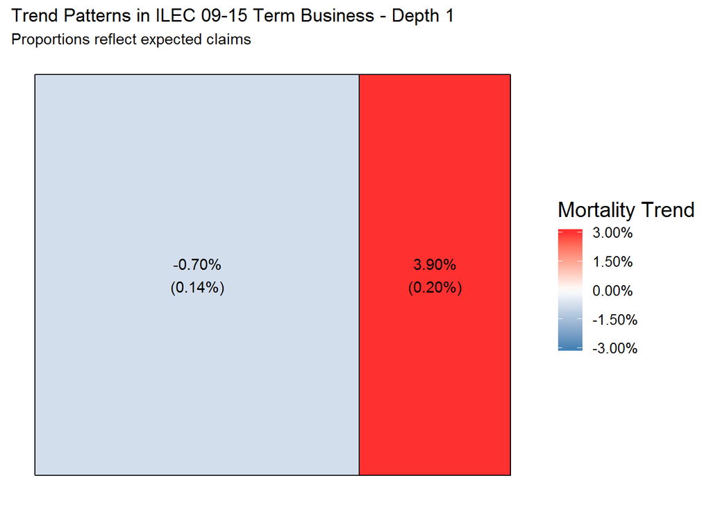

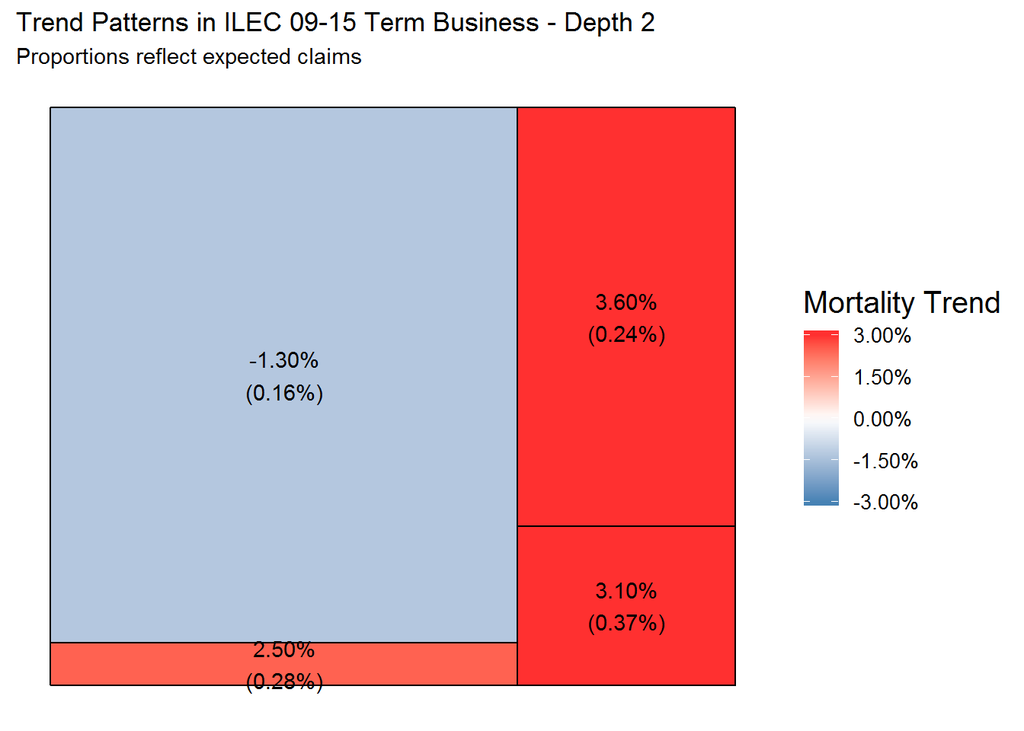

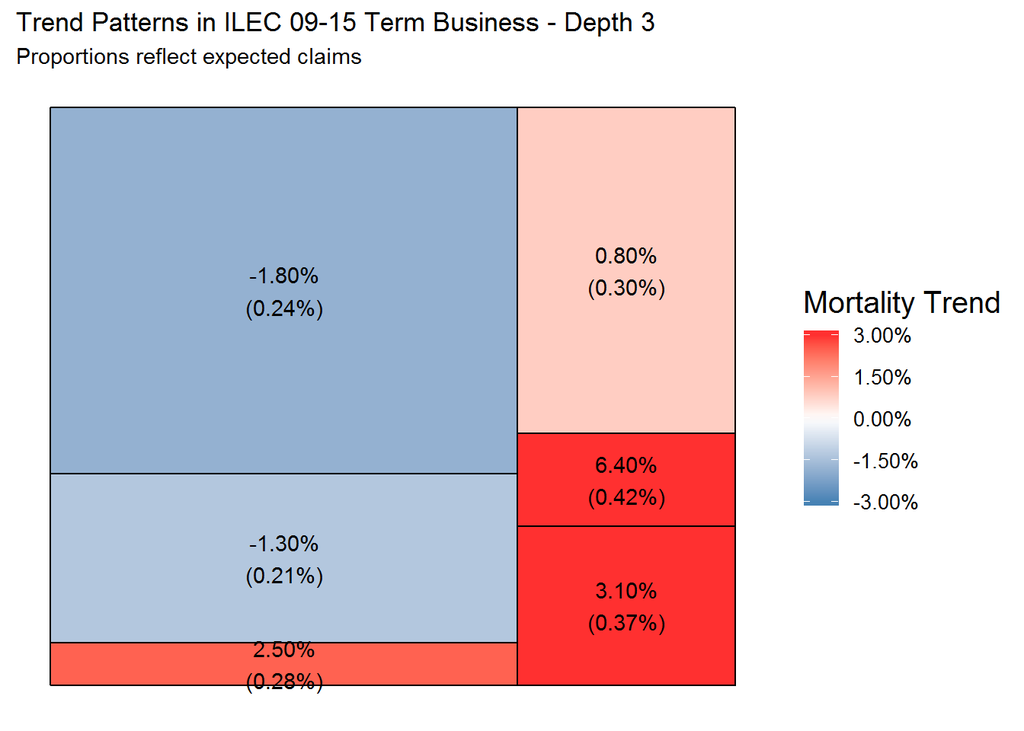

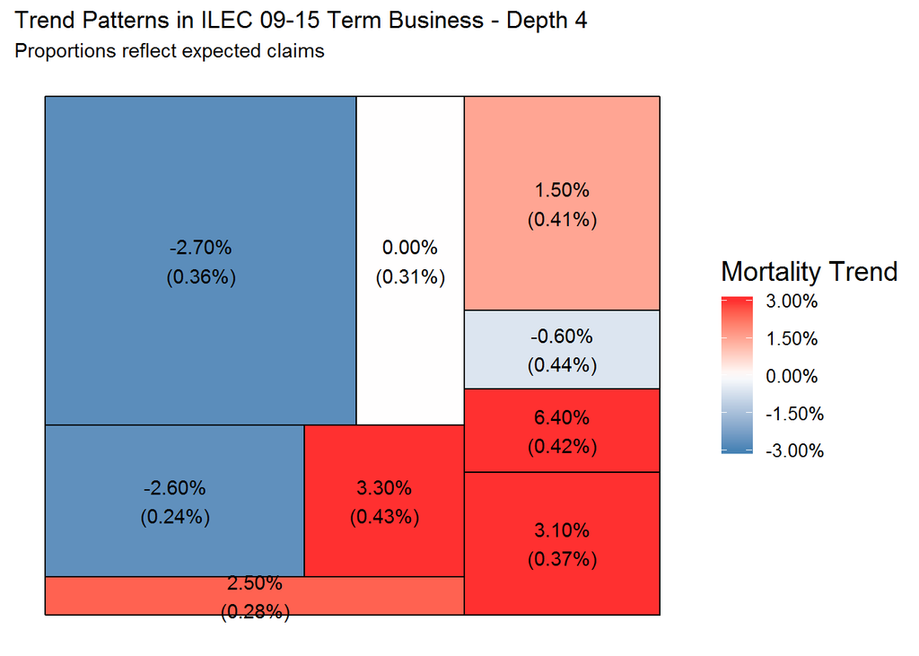

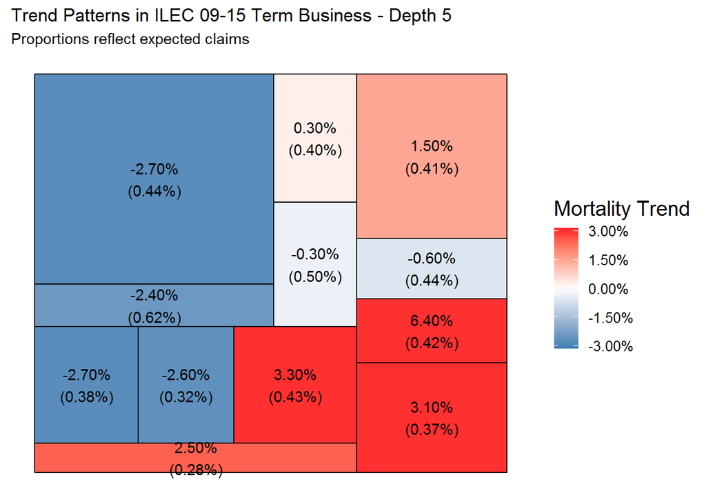

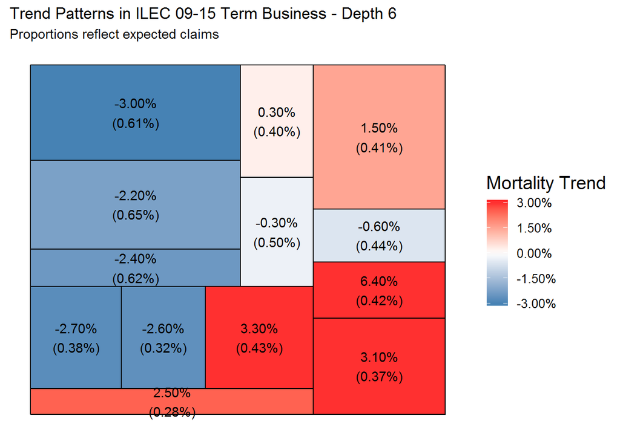

```r
# Trend
png_files <- c()
ggplots <- list()

for(j in 1:maxPlotDepth)
{
  rect.frame <- copy(tree.tbl)
  rect.frame[,Plot.Label:=Label1]

  if(j > 1)
  {
    for(i in 2:j)
    {
      rect.frame[level >= i & !is.na(get(lblColNames[i])), Plot.Label:=paste(Plot.Label,get(lblColNames[i]),sep='\n')]
    }
  }

  rect.frame[,Plot.Label:=paste0(scales::percent(round_any(Trend,.001)),
                                 "\n(",
                                 scales::percent(round_any(TrendSE,.0001),accuracy=.01),
                                 ")")]

  ggplots[[j]] <- ggplot(data=rect.frame[level==j]) +
      geom_rect( mapping=aes(xmin=x0, xmax=x0+w, ymin=y0, ymax=y0+h, fill=Trend), color="black") +
      geom_text( aes(label=Plot.Label,x=x0+w/2,y=y0+h/2)) +
      scale_fill_gradient2(breaks=seq(from=-.03,to=.03,length.out=5),
                           limits=c(-.03,.03),
                           labels=scales::percent,
                           oob=scales::squish,
                           low="steelblue",mid = "white",high="firebrick1",
                           name="Mortality Trend") +
      ggtitle(label=paste0("Trend Patterns in ILEC 09-15 Term Business - Depth ",j),
              subtitle="Proportions reflect expected claims") +
      theme(axis.text=element_blank(),
            axis.ticks = element_blank(),
            axis.title = element_blank(),
            panel.background = element_blank(),
            legend.title = element_text(size=15),
            legend.text = element_text(size=10)
            )

  png_files[j] <- paste0("Term GLM Tree - Trend - Depth ",j, " - Pres.png")
  png(filename = png_files[j],width=1024/2,height=1024/2)
  print(
    ggplots[[j]]
  )

  dev.off()
  print(ggplots[[j]])
}
```

```r
gifski(png_files,"Term GLM Tree -Trend - Animated.gif",width=1024/2,height=1024/2)
```

```
##
Frame 1 (16%)
Frame 2 (33%)
Frame 3 (50%)
Frame 4 (66%)
Frame 5 (83%)
Frame 6 (100%)
## Finalizing encoding... done!
```

```
## [1] "F:\\ILEC\\SOA Data Challenge\\Term GLM Tree -Trend - Animated.gif"
```

The following generate the various levels for the level component.

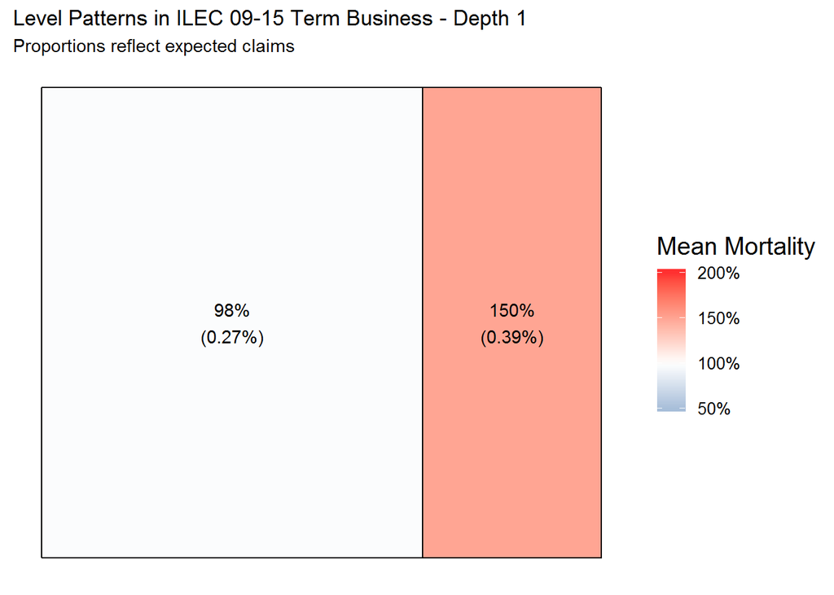

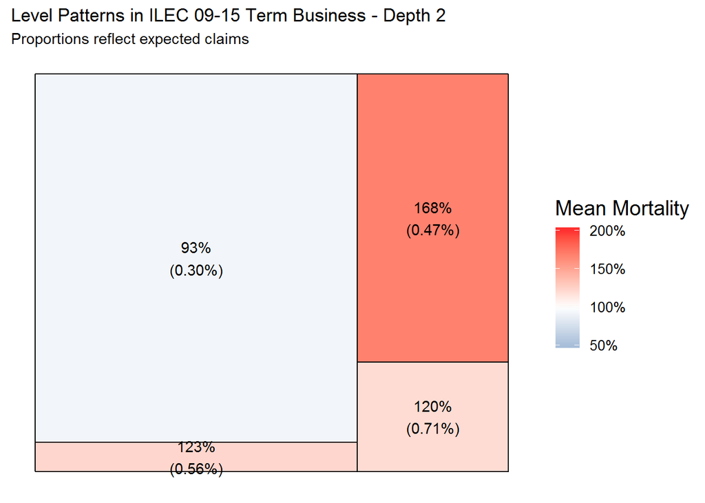

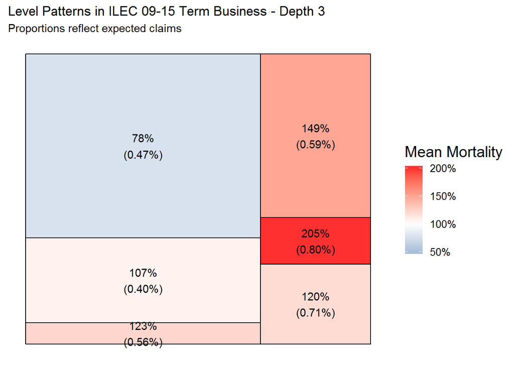

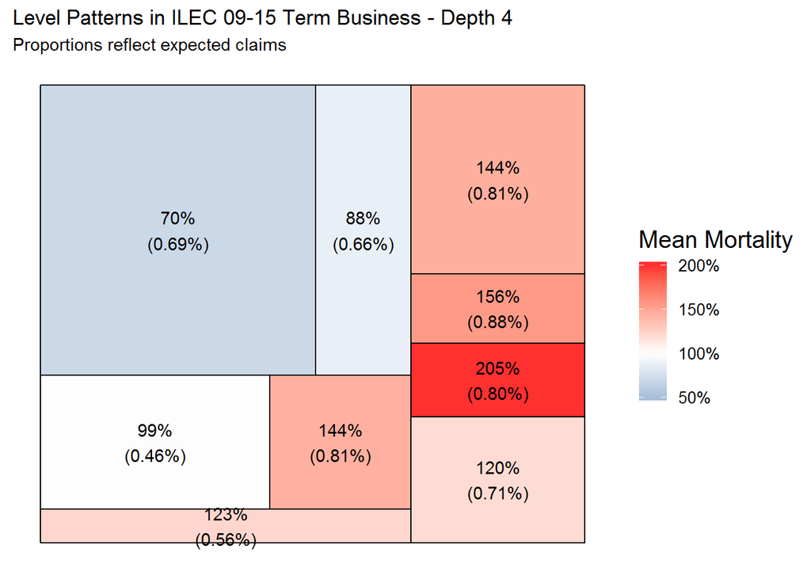

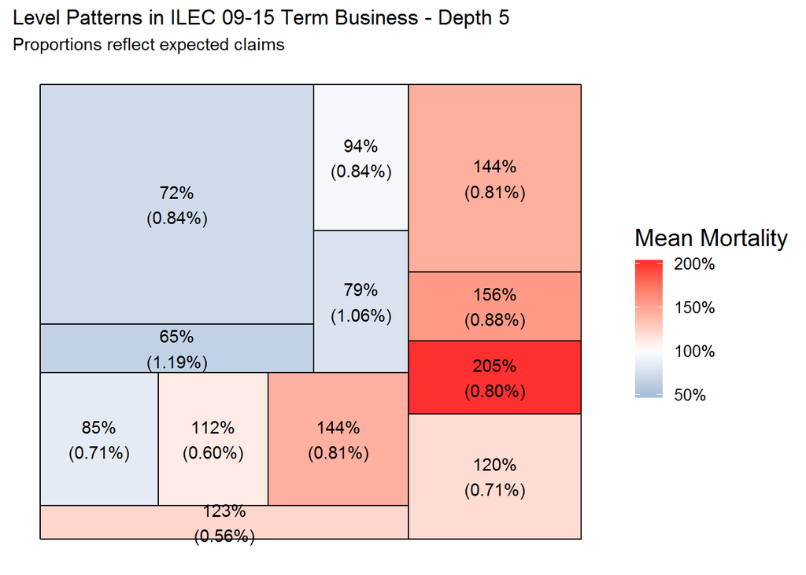

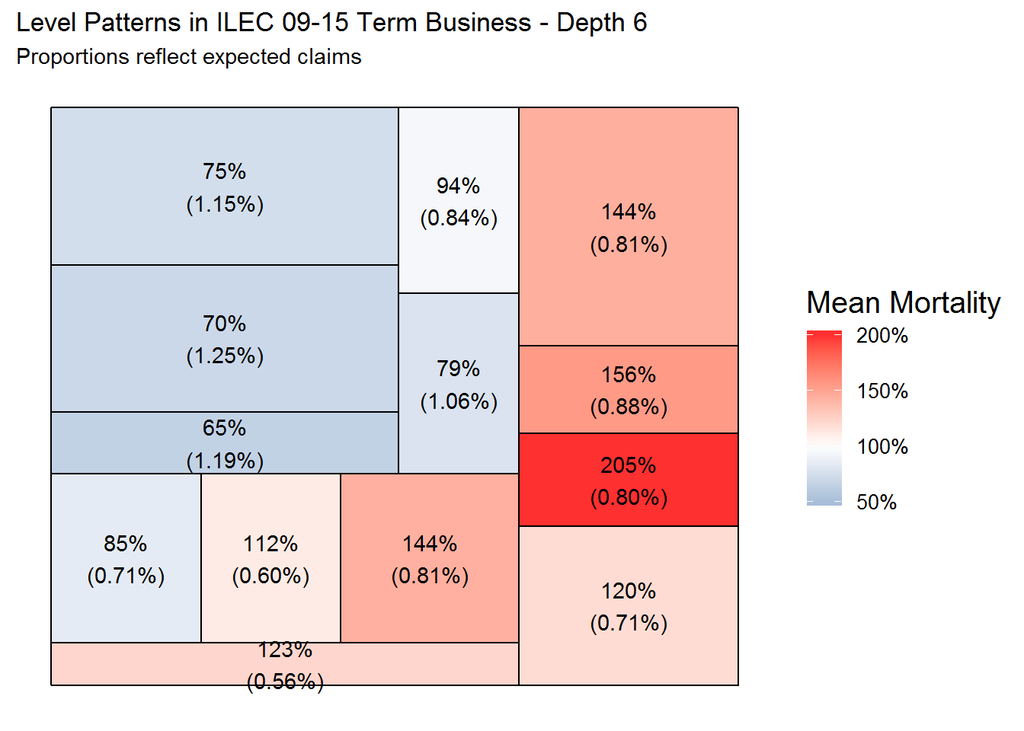

```r
# Level
png_files <- c()
ggplots <- list()

for(j in 1:maxPlotDepth)
{
  rect.frame <- copy(tree.tbl)
  rect.frame[,Plot.Label:=Label1]

  if(j > 1)
  {
    for(i in 2:j)
    {
      rect.frame[level >= i & !is.na(get(lblColNames[i])), Plot.Label:=paste(Plot.Label,get(lblColNames[i]),sep='\n')]
    }
  }

  rect.frame[,Plot.Label:=paste0(scales::percent(round_any(Level2012,.001)),
                                 "\n(",
                                 scales::percent(round_any(Level2012SE,.0001),accuracy=.01),
                                 ")")]

  ggplots[[j]] <- ggplot(data=rect.frame[level==j]) +
      geom_rect( mapping=aes(xmin=x0, xmax=x0+w, ymin=y0, ymax=y0+h, fill=Level2012), color="black") +
      geom_text( aes(label=Plot.Label,x=x0+w/2,y=y0+h/2)) +
      scale_fill_gradient2(breaks=seq(from=.5,to=2,length.out=4),
                           limits=c(.5,2),
                           labels=scales::percent,
                           oob=scales::squish,
                           low="steelblue",mid = "white",high="firebrick1",
                           midpoint=1,
                           name="Mean Mortality") +
      ggtitle(label=paste0("Level Patterns in ILEC 09-15 Term Business - Depth ",j),
              subtitle="Proportions reflect expected claims") +
      theme(axis.text=element_blank(),
            axis.ticks = element_blank(),
            axis.title = element_blank(),
            panel.background = element_blank(),
            legend.title = element_text(size=15),
            legend.text = element_text(size=10)
            )

  png_files[j] <- paste0("Term GLM Tree - Level - Depth ",j, " - Pres.png")
  png(filename = png_files[j],width=1024/2,height=1024/2)
  print(
    ggplots[[j]]
  )

  dev.off()
  print(ggplots[[j]])
}
```

```r
gifski(png_files,"Term GLM Tree - Level - Animated.gif",width=1024,height=1024)
```

```
##
Frame 1 (16%)
Frame 2 (33%)
Frame 3 (50%)
Frame 4 (66%)
Frame 5 (83%)
Frame 6 (100%)
## Finalizing encoding... done!
```

```
## [1] "F:\\ILEC\\SOA Data Challenge\\Term GLM Tree - Level - Animated.gif"
```